# ANALYSES DONNEES CLINIQUES

Serigne Fallou Mbacke NGOM

2023-04-06

## ======== RECODAGE DES VARIABLES ============

## ======== RESUME DE LA BASE DE DONNEES ==========

```
##    NUMEPID            NUMEPID2                   RM                 DS
##  Length:3723        Length:3723        MATAM      :1112   MATAM      : 637
##  Class :character   Class :character   FATICK     : 379   THILOGNE   : 476
##  Mode  :character   Mode  :character   TAMBACOUNDA: 365   TAMBACOUNDA: 365
##                                        THIES      : 347   LOUGA      : 303
##                                        LOUGA      : 310   MBOUR      : 242
##                                        (Other)    :1182   (Other)    :1674
##                                        NA's       :  28   NA's       :  26
##                FORMSANIT    NUMDISTRICT      SENTINEL
##  BOKIDIAWE          : 638   Mode:logical   Length:3723
##  AGNAM-CIVOL        : 497   NA's:3723      Class :character
##  PS PONT TAMBA      : 367                  Mode  :character
##  SANTHIABA LOUGA    : 304
##  PS MBOUR TOUCOULEUR: 242
##  (Other)            :1674
##  NA's               :   1
##           N_MED         DAT_CST                 AN          NUMREG
##  AMY NGOM    : 300   Min.   :2019-01-02   Min.   :2019   Length:3723
##  FATOU MBAYE : 291   1st Qu.:2020-07-21   1st Qu.:2020   Class :character
##  TENING DIOME: 224   Median :2021-09-21   Median :2021   Mode  :character
##  H KONATE    : 173   Mean   :2021-05-07   Mean   :2021
##  KHADY FAYE  : 137   3rd Qu.:2022-01-26   3rd Qu.:2022
##  (Other)     :2353   Max.   :2022-12-31   Max.   :2022
##  NA's        : 245
##       SEM                 ADRESSE        SEXE           AGE
##  Min.   : 0.00   NDIAYE NDIAYE: 195   Homme:1747   Min.   : 1.00
##  1st Qu.:15.00   BOKIDIAWE    : 187   Femme:1879   1st Qu.:16.00
##  Median :31.00   AGNAM CIVOL  : 160   Nsp  :  97   Median :24.00
##  Mean   :28.28   BKD          : 133                Mean   :27.29
##  3rd Qu.:41.00   DAROU MARNANE: 119                3rd Qu.:36.00
##  Max.   :52.00   (Other)      :2586                Max.   :90.00
##                  NA's         : 343                NA's   :396
##     AGE_MOIS        DAT_NAIS               FVR            TEMP
##  Min.   : 1.00   Min.   :1950-01-01   FVR_Oui:  21   Min.   : 0.0
##  1st Qu.: 5.00   1st Qu.:1989-12-08   FVR_Non:3702   1st Qu.:38.2
##  Median :11.00   Median :2003-10-10                  Median :38.7
##  Mean   :16.75   Mean   :2001-06-01                  Mean   :37.6
##  3rd Qu.:27.00   3rd Qu.:2016-03-16                  3rd Qu.:39.3
##  Max.   :53.00   Max.   :2022-06-27                  Max.   :99.9
##  NA's   :3588    NA's   :3655
```

[output cut: 121 more lines]

```
##  NA's:3723   NA's:3723   NA's:3723   SURVEIL_AMB_Oui:3708   NA's:3723
##                                      SURVEIL_AMB_Non:   0
##                                      NA's           :  15
##
##
##
##
##    EVOL
##  NA's:3723
##
##
##
##
##
##
```

## ======== VISUALISATION DES DONNEES ==========

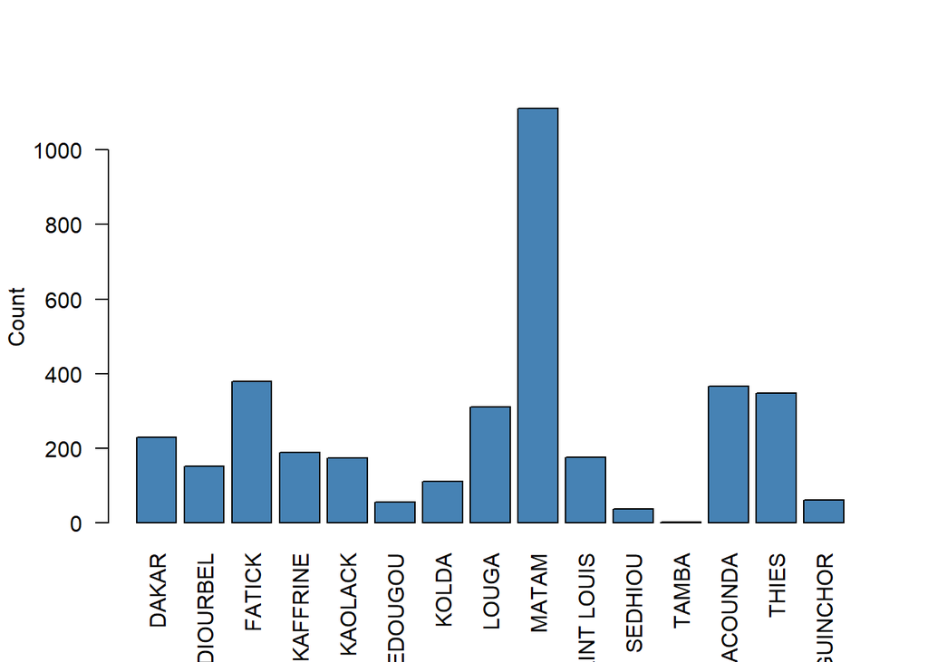

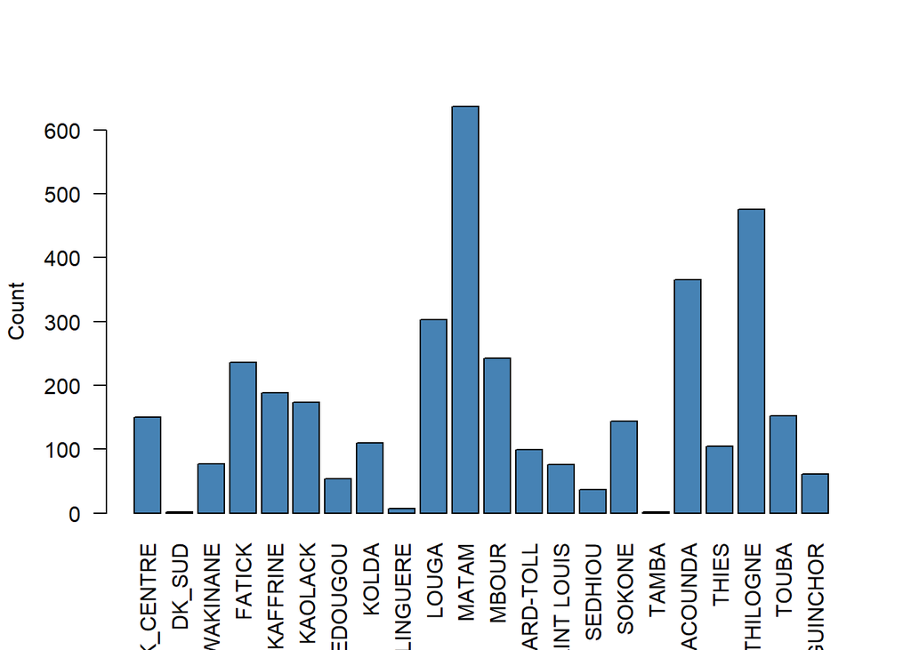

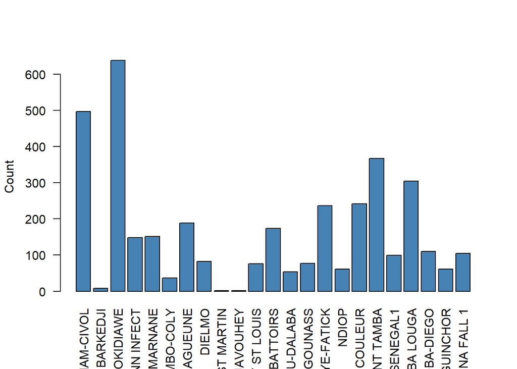

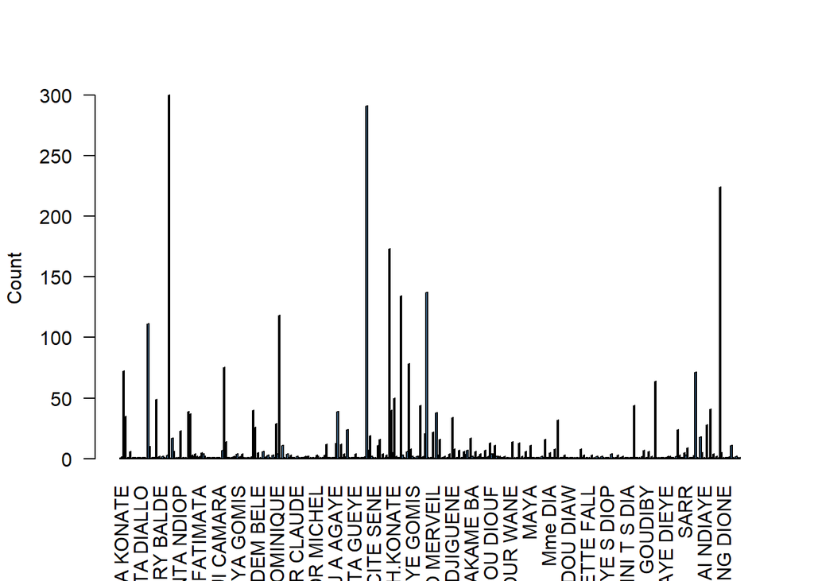

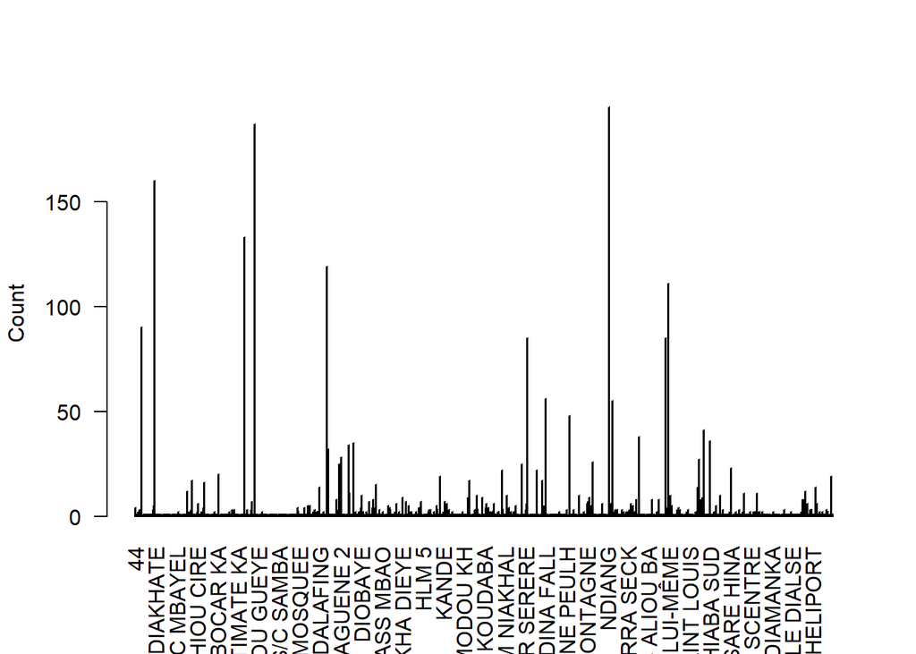

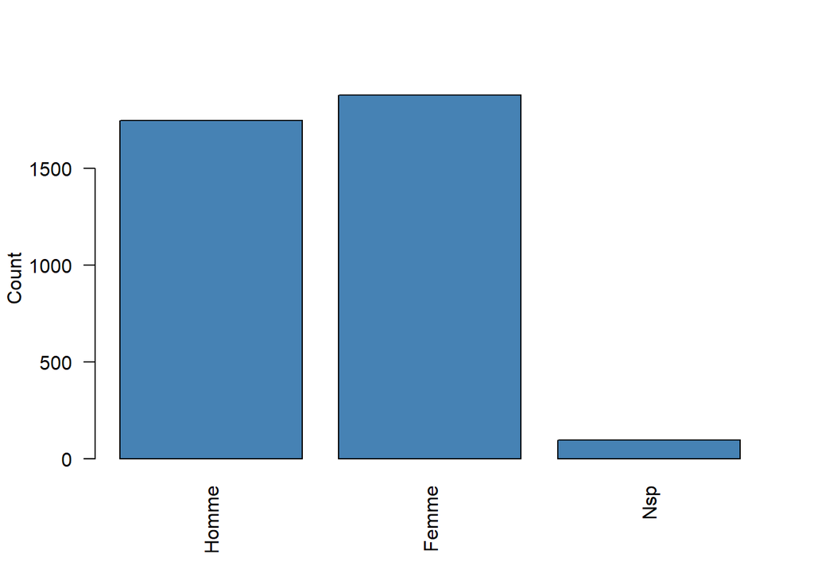

### ACM1:

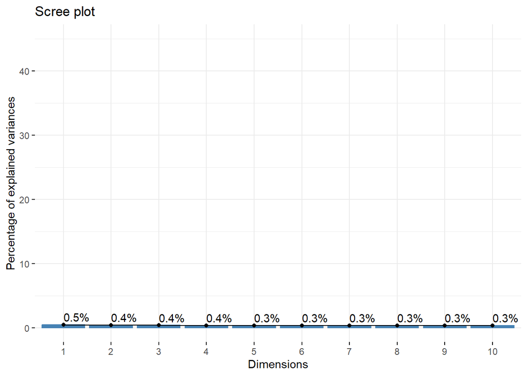

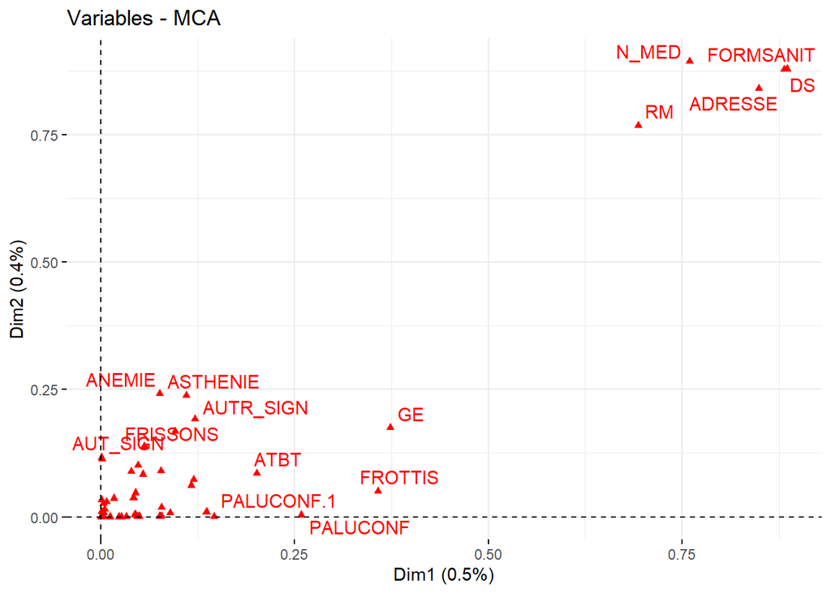

*ANALYSES ET INTERPRETATION:* Nous constatons la formation de deux(2) groupes, meme si la quantitè d’information expliquèe par ces composantes est très faible: - Les informations sur le medecin, les districts, les règions, l’adresse et la forme sanitaire; - les autres variables sur les symptomes et autres informations.

Ceci est normal dans la mesure ou il n’existe pas de lien entre les deux groupes (pas de biais lie a l’èchantillonage).

Nous allons essayer de voir des combinaisions de variables qui vont donner des quantitès èlevèes d’informations expliquèes par des composantes principales.

### ACM2:

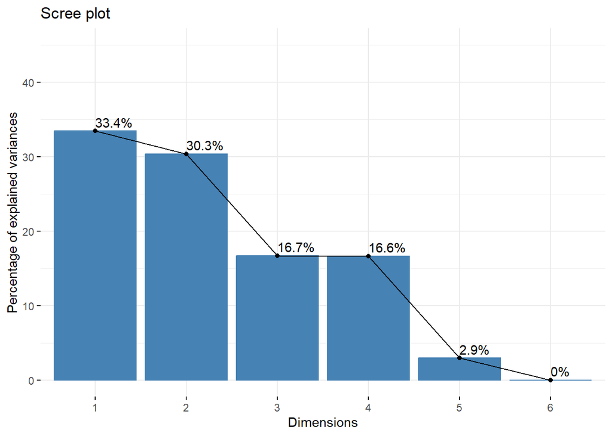

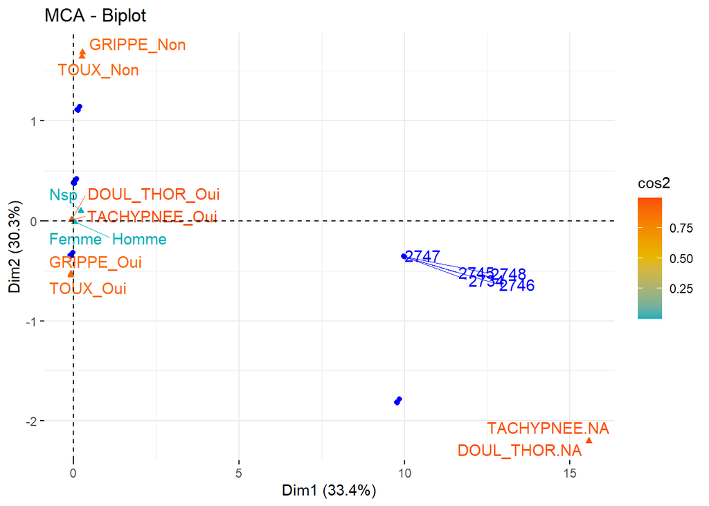

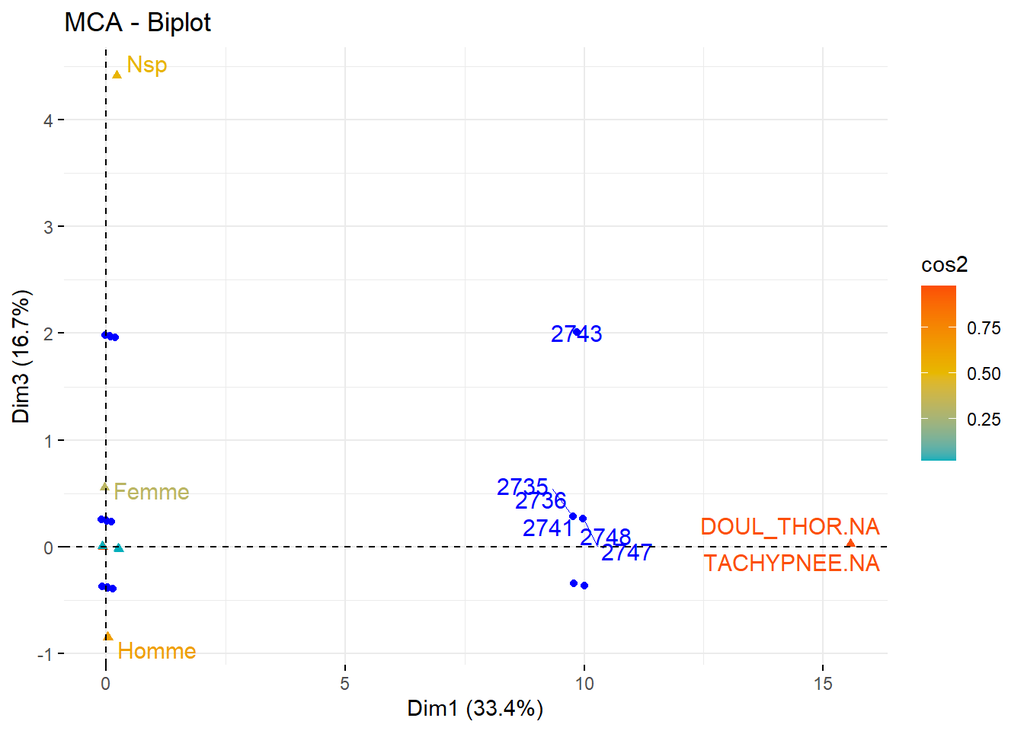

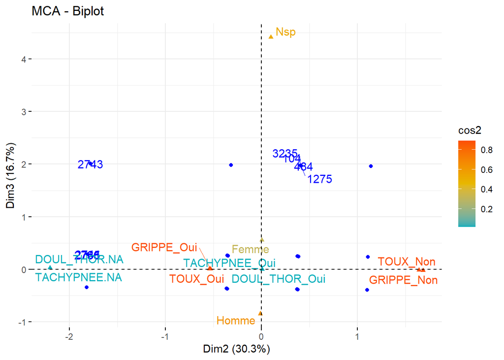

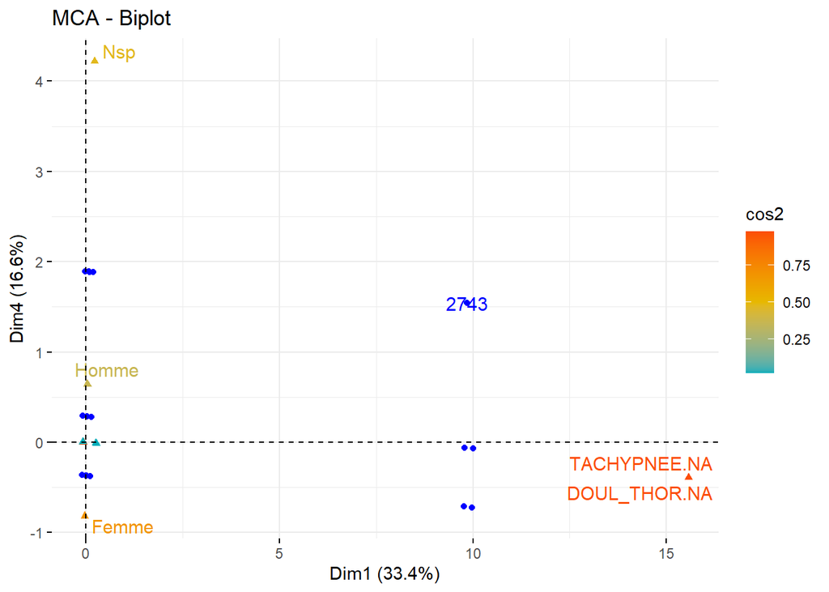

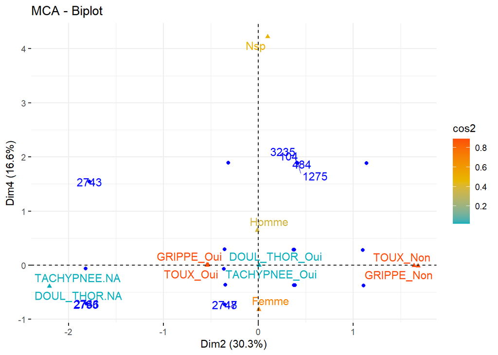

**ANALYSES ET INTERPRETATION:** Nous constatons que les quatres(4) premiers composantes expliques 97% de l’information. L’analyse des composantes nous permet de dèduire qu’en gènèral:

- Les patients grippès (GRIPPE_Oui), prèsentent des toux (TOUX_Oui) et vice versa. Et aussi ceux non grippès(GRIPPE_Non), ne prèsentent pas de toux (TOUX_Non) et vice versa. **Donc on pourra regrouper les deux variables en une seule : TOUX + GRIPPE = GRIP_T ou TOUX_G …**
- Les personnes qui prèsentent des douleurs thoraciques (DOUL_THOR_Oui), prèsentent egalement de la tachynèe (TACHYNEE_Oui).
- Il existe un faible rapprochement entre les deux(2) groupes de patients [avec toux (TOUX_Oui), ceux grippès (GRIPPE_Oui)] et [ceux presentant des tachynees (TACHYNEE_Oui)et douleurs thoraciques (DOUL_THOR_Oui)].

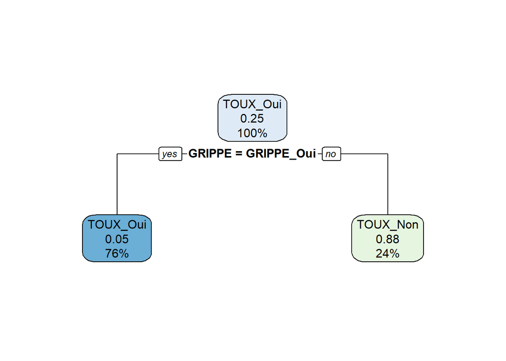

  L’arbre de dècision rejoint notre hypothèse selon laquelle dès l’instant que le patient est grippè, donc il prèsente des toux.

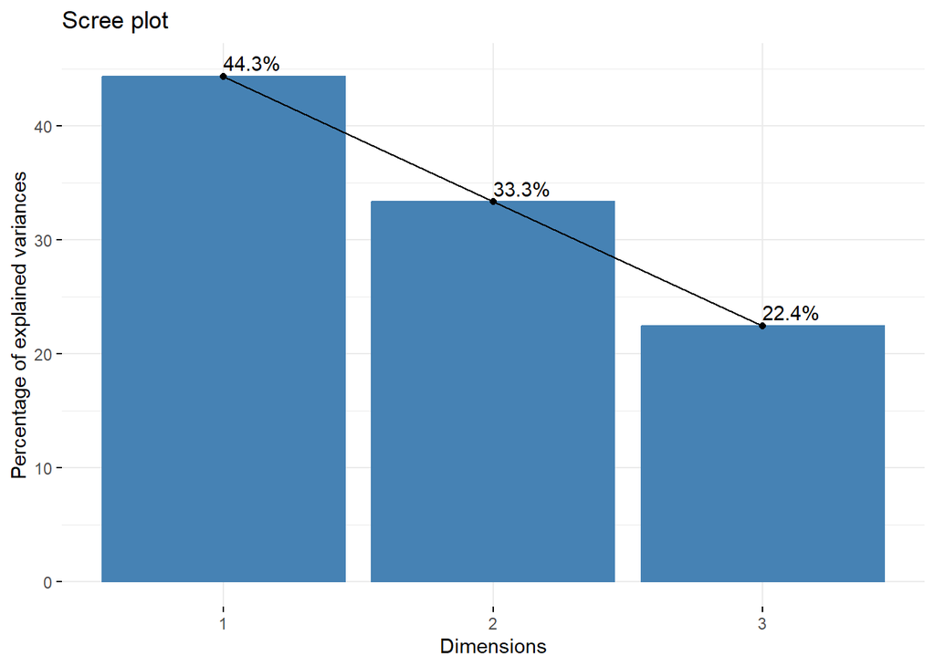

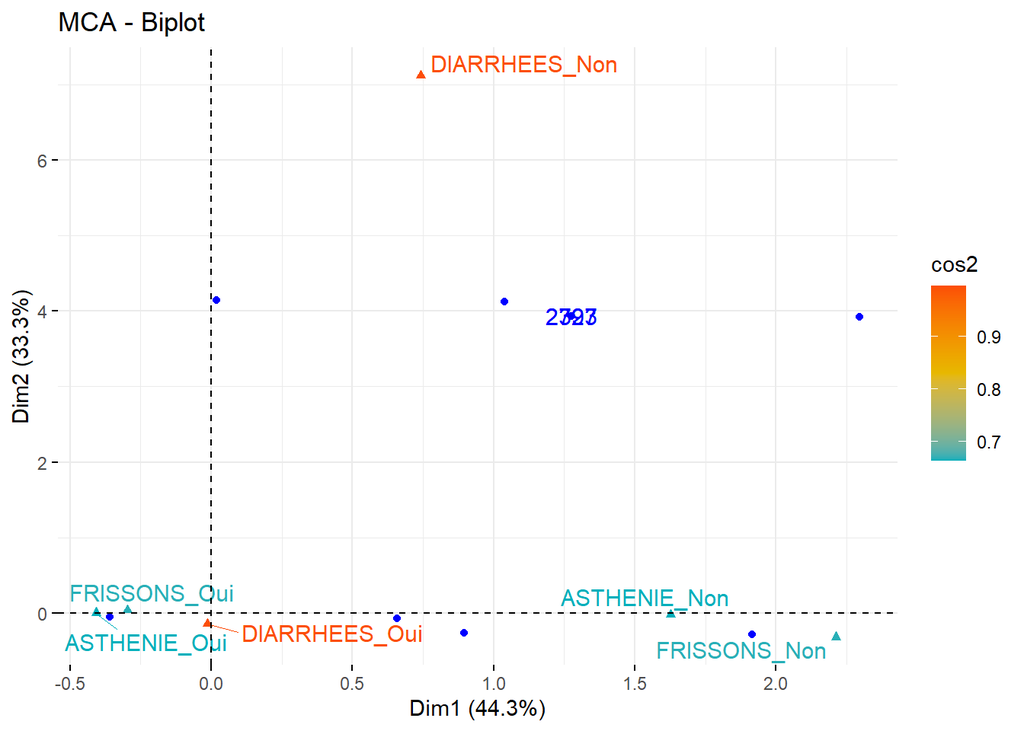

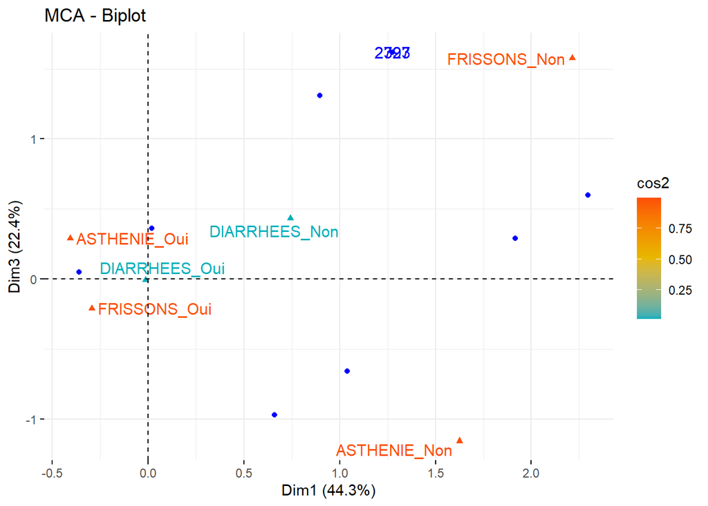

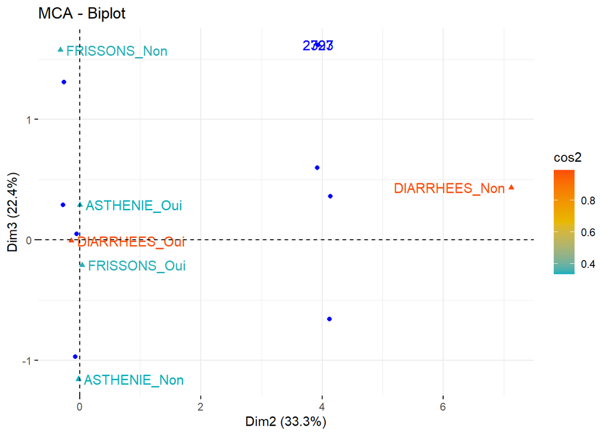

**ANALYSES ET INTERPRETATION :** L’analyse des trois(3) composantes nous permet de concluire que de maniere generale: Les patients avec Asthenie (ASTHENIE_Oui) presentent de diarrhees (DIARRHEES_Oui) et des frissons (FRISSONS_Oui).

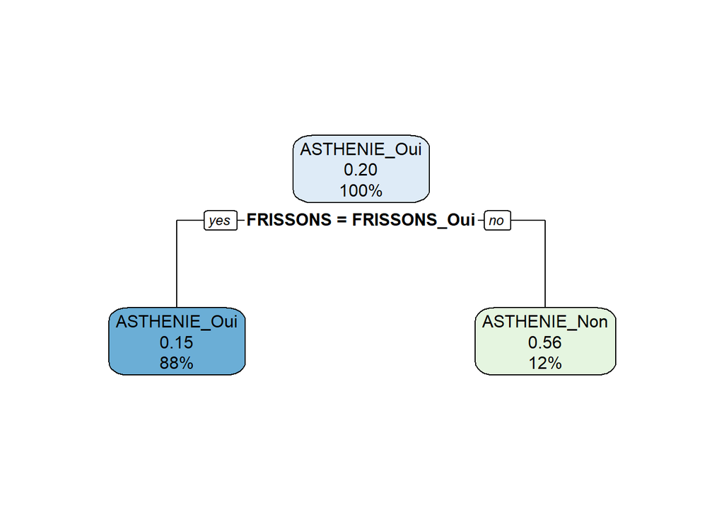

Cela pourrait s’expliquer par le fait que la diarrhèe provoque la perte d’une grande quanttite d’eau ce qui va affaiblir l’organisme provoquant ainsi une une fatique physique ou asthènie

### ACM3:

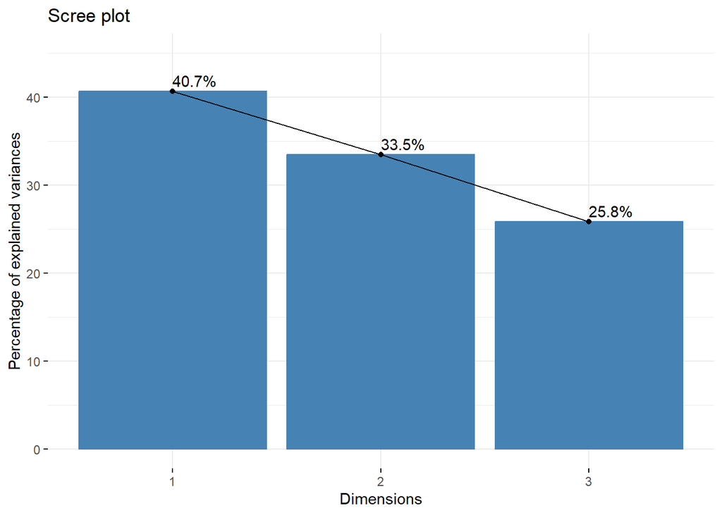

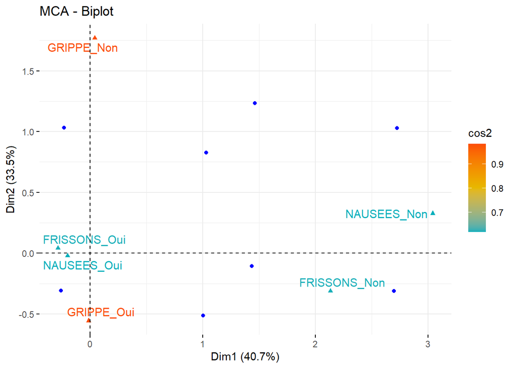

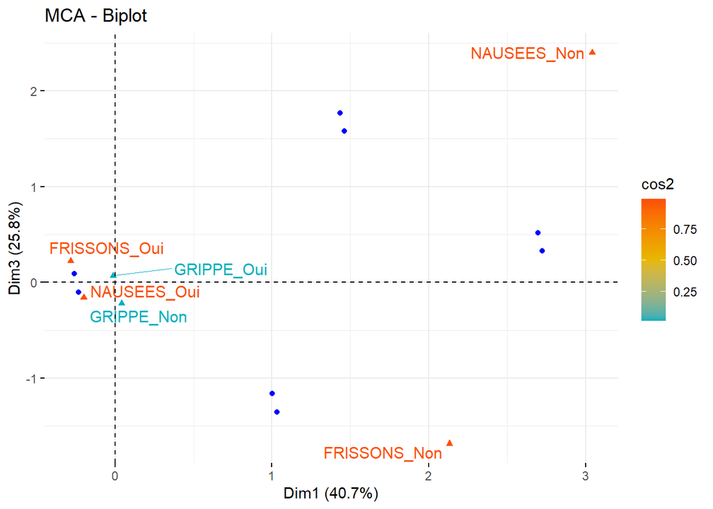

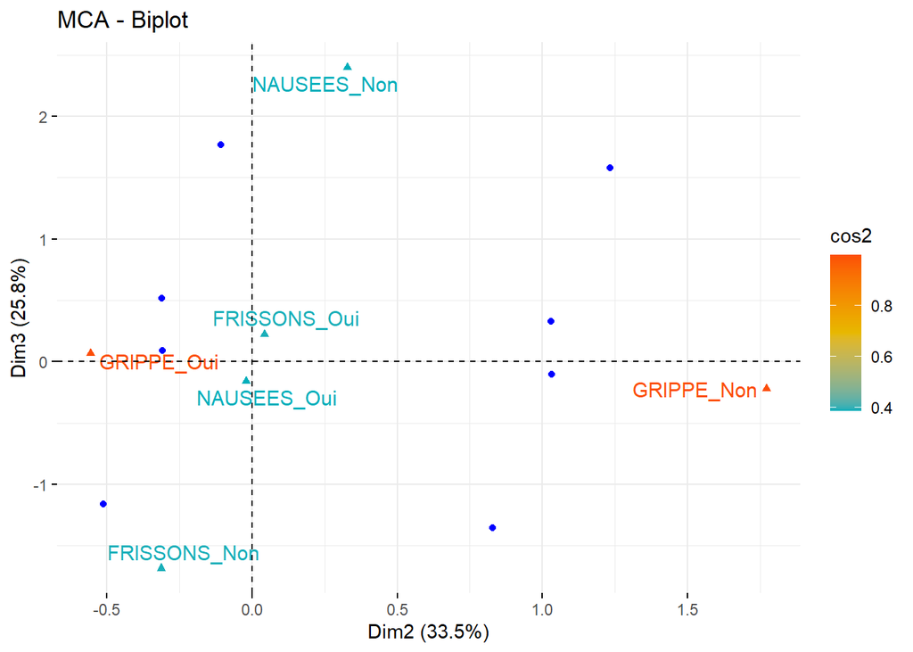

L’analyse des trois(3) composantes nous permet de concluire que de maniere generale: Les patients qui presentent des nausèes (NAUSEES_Oui), ont egalement des frissons (FRISSONS_Oui).